# Writing your meta-analytic paper

Now that we’ve conducted our meta-analyses, it’s time to write the paper. This vignette covers three topics that help with that: functions for summary statistics, a function that help you turn your database into a bibliography, and some ggplot2-based visualizations that we’ve found useful.

Once again, we’ll illustrate with data from two previous meta-analyses: `sv_data` from “[Preventing Sexual Violence —A Behavioral Problem Without a Behaviorally-Informed Solution](https://doi.org/10.1177/15291006231221978)” and `contact_data` from “[The Contact Hypothesis Re-evaluated](https://doi.org/10.1017/bpp.2018.25).”

## 1 Summary statistics functions

### 1.1 `summarise_lm`

`summarise_lm` takes the built in R functions `summary(lm())` and lets you use them in a sequence of pipes. In particular this is useful when you want to test for the magnitude of a relationship between two variables in many different subsets of data at once.

```r
library(PaluckMetaSOP)
sv_data |> summarise_lm()
```

```
##             Estimate Std. Error t value Pr(>|t|)
## (Intercept)  0.25418    0.04319 5.88484  0.00000
## se_d         0.15682    0.17827 0.87970  0.37946
```

```r
# now in different subsets
library(purrr)
sv_data |> split(~study_design) |> map(summarise_lm)
```

```
## $`Randomized Controlled Trial`
##             Estimate Std. Error t value Pr(>|t|)
## (Intercept)  0.18576    0.08309  2.2357  0.02661
## se_d         0.20554    0.25182  0.8162  0.41547
##
## $`Quasi-Experimental`
##             Estimate Std. Error  t value Pr(>|t|)
## (Intercept)  0.23696    0.07025  3.37330  0.00092
## se_d        -0.14497    0.40680 -0.35638  0.72200
##
## $Observational
##             Estimate Std. Error t value Pr(>|t|)
## (Intercept)  0.09443    0.11101 0.85058  0.39650
## se_d         2.21790    0.65767 3.37233  0.00097
```

### 1.2 `summarise_table`

`summarise_table`, like `summarise_lm`, takes a built in function (`table`) and turns it into something that can be integrated into a sequence of pipes. Again, this is useful for when you want to see many tables at once, or put a few tables into a bigger table.

```r
library(dplyr)
# let's say you want to see the table of `behavior_type` in `sv_data
# you can do
table(sv_data$behavior_type)
```

```
##
##     Bystander         Ideas   Involvement  Perpetration Victimization
##            27           346             9            62            45
```

```r
# the summarise_table version
sv_data |> summarise_table(behavior_type)
```

```
##
##     Bystander         Ideas   Involvement  Perpetration Victimization
##            27           346             9            62            45
```

```r
# where this really becomes useful is something like:
PaluckMetaSOP::sv_data |> split(~study_design) |>
map(~ summarise_table(., behavior_type)) |> bind_rows(.id = "study_design")
```

```
## # A tibble: 3 × 6
##   study_design            Bystander Ideas Involvement Perpetration Victimization
##   <chr>                   <table[1> <tab> <table[1d]> <table[1d]>  <table[1d]>
## 1 Randomized Controlled … 10        118    3          28           22
## 2 Quasi-Experimental      11        116    6          21           16
## 3 Observational            6        112   NA          13            7
```

```r
# Note: summarise_table() returns a table object. For more complex manipulations,
# you can convert to a data frame:
# as.data.frame(summarise_table(sv_data, behavior_type))
```

### 1.3 `study_count`

This simple function counts how many studies are in a dataset or in different subsets of your data. It assumes your dataset has a variable called `unique_study_id`.

```r
sv_data |> study_count()
```

```
##   N_unique
## 1      295
```

```r
sv_data |> split(~study_design) |> map(study_count) |>
  bind_rows(.id = "study_design")
```

```
##                  study_design N_unique
## 1 Randomized Controlled Trial      102
## 2          Quasi-Experimental      100
## 3               Observational       96
```

### 2 Turning a database of studies into a bibliography file

The `make_bib()` function takes a data frame containing DOI information and creates a BibTeX (.bib) file. This is a wrapper around `RefManageR::WriteBib()` that fetches bibliographic information for each DOI and writes it to a .bib file suitable for use with LaTeX.

To use this function, you need a column of DOIs in your meta-analytic database. Neither `contact_data` nor `sv_data` has DOI information, but the `map_reduction_data` dataset does. This dataset comes from a meta-analysis of interventions to reduce consumption of meat and animal products (Green et al., 2025) and is included in this package specifically to demonstrate the `make_bib()` function.

**Note:** We’ll set `eval = FALSE` so this doesn’t continually re-run when the vignette builds, since it requires API calls to DOI.org.

```r
library(dplyr)

# Load the MAP reduction dataset
data(map_reduction_data)

# Preview the data structure
map_reduction_data |>
  select(author, year, title, doi) |>
  head(5)

# Filter for entries with valid DOIs (start with "10.")
map_with_dois <- map_reduction_data |>
  filter(grepl("^10\\.", doi)) |>
  distinct(doi, .keep_all = TRUE)

cat("Found", nrow(map_with_dois), "unique DOIs\n")

# Generate bibliography
make_bib(
  data = map_with_dois,
  doi_column = "doi",
  bib_file = "./references.bib",
  verbose = TRUE
)

# The function will:
# 1. Extract unique DOIs from the specified column
# 2. Fetch bibliographic information from DOI.org
# 3. Write each entry to the .bib file
# 4. Print progress messages

# You can also manually add individual DOIs:
# Create a simple data frame with a DOI
extra_doi <- data.frame(doi = "10.1016/j.appet.2025.108233")
make_bib(extra_doi, bib_file = "./references.bib", overwrite = FALSE)
```

The resulting .bib file can be used directly in your LaTeX document with `\bibliography{references}`.

## 3 Visualizations

### 3.1 Forest plot

Forest plots are a staple of meta-analyses. Many R packages have functions to create them, e.g. `metafor::forest`. However, our meta-analytic figures typically add color coding to denote additional information about (e.g.) study design, theoretical category, or outcome type. There was no easy way to do that with existing functions, so here’s one approach to doing that in ggplot2 (and some supplementary plotting libraries as well).

```
## `height` was translated to `width`.
```

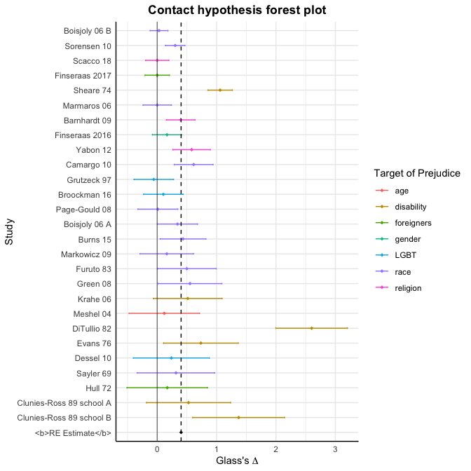

```r
library(ggplot2)
library(ggtext)
model <- contact_data |> map_robust()

bold_labels <- function(x) {
  ifelse(x == "RE Estimate", "<b>RE Estimate</b>", x)
}

plot_dat <- as.data.frame(contact_data) |>
  mutate(lower_bound = d - (1.96 * se_d),
         upper_bound = d + (1.96 * se_d)) |>
  select(name_short, d, se_d, lower_bound, upper_bound,
         target_spelled_out) |>
  add_row(name_short = "RE Estimate", d = model$Delta,
          lower_bound = model$Delta - (1.96 * model$se),
          upper_bound = model$Delta + (1.96 * model$se),
          target_spelled_out = NA)

# Get unique study names excluding "RE Estimate"
unique_studies <- unique(plot_dat$name_short[plot_dat$name_short != "RE Estimate"])

# Append "RE Estimate" to the end of the list
ordered_levels <- c(unique_studies, "RE Estimate")

# Set this order to name_short
plot_dat$name_short <- reorder(factor(plot_dat$name_short, levels = ordered_levels), desc(plot_dat$se_d))

plot_dat |> ggplot(aes(x = d, y = name_short)) +
  geom_point(data = subset(plot_dat, name_short == "RE Estimate"),
             shape = 18) + # shape = 5 for a transparent diamond
  geom_point(data = subset(plot_dat, name_short != "RE Estimate"),
             aes(color = target_spelled_out), shape = 18) +
  geom_errorbar(data = subset(plot_dat, name_short != "RE Estimate"),
                aes(xmin = lower_bound, xmax = upper_bound, color = target_spelled_out),
                height = .1, orientation = "y") +
  geom_vline(xintercept = 0, color = "black", alpha = .5) +
  geom_vline(xintercept = model$Delta,
             color = 'black', lty = 'dashed') +
  theme_minimal() +
  theme(axis.text.y = element_markdown()) +  # Apply HTML formatting to y-axis text
  scale_y_discrete(labels = bold_labels) +    # Use custom function for y-axis labels
  scale_x_continuous(name = expression(paste("Glass's", " ", Delta))) +
  labs(color = "Target of Prejudice") +
  ylab("Study") +
  ggtitle("Contact hypothesis forest plot") +
  theme(plot.title = element_text(hjust = 0.5,
                                  face = "bold"),
        axis.line = element_line(colour = "black"))
```

We didn’t actually use this code in “The Contact Hypothesis Re-evaluated”, but we probably would have if we were writing that paper now.

### 3.2 Relationship between Standard Error and D

A standard check for publication bias is to see if effect size is positively correlated with the size of the standard error. The idea is that in the presence of publication bias, smaller studies are more likely to get shelved if they produce null results, whereas large, well-powered studies are more likely to get published no matter what. In that case, you’d expect for small studies to be an inaccurate estimate of the true population effect size, and for larger studies to produce systematically smaller estimates.

Here’s a slightly simplified version of figure 1 from “The Contact Hypothesis Re-Evaluated:”

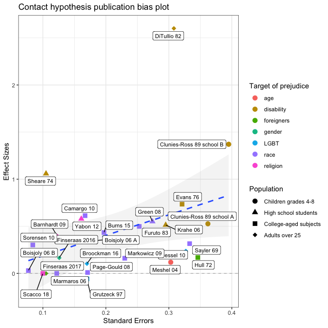

```r
library(ggrepel)
shape_orders <- c(19, 17, 15, 18)
target_labels <- c("Age", "Disability", "Foreigners", "Gender",
                   "LGBT",  "Race", "Religion" )

  ggplot(contact_data,
         aes(x = se_d, y = d,
             label = name_short)) +
  geom_hline(yintercept = 0, lty = "dashed", colour = "grey") +
  geom_point(aes(shape = factor(pop),
                 color = target_spelled_out), size = 3, alpha = NA) +
  scale_shape_manual(values = shape_orders, name = "Population",
                     labels = c("Children grades 4-8","High school students",
                                "College-aged subjects", "Adults over 25")) +
  stat_smooth(aes(fill = NULL), lty = "dashed", fullrange = TRUE,
              method = "lm",
              show.legend = FALSE, alpha = .1) +
    geom_label_repel(size = 3) +
  xlab("Standard Errors") +
  ylab("Effect Sizes")  +
  ggtitle("Contact hypothesis publication bias plot") +
  labs(color = "Target of prejudice") +
  theme_bw()
```

### 3.3 Descriptive figures

This code produces figures that display descriptive characteristics of `sv_data` for “Preventing Sexual Violence. As you can see, this required a lot of custom code to account for particular things about how we put the dataset together, so it won’t perfectly generalize to a new project; but we think the overall ideas are worth preserving and communicating. (The following was all written by John-Henry Pezzuto.)

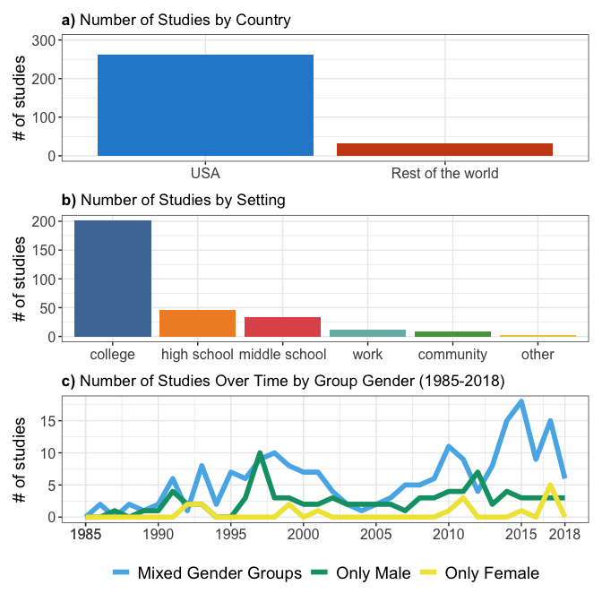

```r
library(forcats)
library(ggplot2)
library(ggtext)
library(ggthemes)
library(patchwork)
library(stringr)
library(tidyr)

country_fig = sv_data |>
  distinct(unique_study_id, country) |>
  mutate(country = ifelse(country == "USA", "USA", "Rest of the world")) |>
  count(country, sort = T) |>
  mutate(country = fct_rev(fct_reorder(factor(country), n)),
         perc = n / sum(n)) |>
  ggplot(aes(country, n, label = n, fill = country)) +
  geom_col() +
  theme_bw() +
  theme(axis.text = element_markdown(size = 12),
        axis.title = element_text(size = 14),
        legend.text = element_text(size = 14),
        plot.title = element_markdown()) +
  scale_y_continuous(breaks = seq(0, 300, by = 100), limits = c(0, 300)) +
  scale_fill_manual(values = solarized_pal()(2)) +
  guides(fill = "none") +
  labs(title = "**a)** Number of Studies by Country",
       x = NULL,
       y = "# of studies",
       col = NULL)

setting_fig = sv_data |>
    distinct(unique_study_id, setting, setting2) |>
    pivot_longer(cols = c("setting", "setting2"), values_to = "setting") |>
    drop_na(setting) |>
    count(setting, sort = T) |>
    mutate(setting = fct_rev(fct_reorder(setting, n)),
           perc = n / sum(n)) |>
    ggplot(aes(setting, n, fill = setting)) +
    geom_col() +
    scale_fill_manual(values = ggthemes::tableau_color_pal('Tableau 10')(6)) +
    labs(title = "**b)** Number of Studies by Setting",
         x = NULL,
         y = "# of studies",
         col = NULL) +
    theme_bw() +
    guides(fill = "none") +
    theme(axis.text = element_markdown(size = 12),
          axis.title = element_text(size = 14),
          legend.text = element_text(size = 14),
          plot.title = element_markdown())

dat_participant_sex <- sv_data |> # participant sex lines
  mutate(participant_sex =
           if_else(participant_sex %in%
                     c("male and female in mixed groups",
                       "male and female in separate groups and also in combined groups",
                       "male and female in separate groups",
                       "male and female with group composition not specified",
                       "general population"),
                   "mixed gender groups",
                   participant_sex)) |>
  distinct(year, unique_study_id, participant_sex) |>
  filter(participant_sex %in%
           c("mixed gender groups", "only male", "only female")) |>
  count(year, participant_sex) |>
  add_row(year = 1985, participant_sex = "mixed gender groups") |>
  complete(year, participant_sex, fill = list(n = 0)) |>
  mutate(participant_sex = str_to_title(participant_sex)) |>
  mutate(participant_sex = factor(participant_sex,
                                  levels = c("Mixed Gender Groups",
                                             "Only Male",
                                             "Only Female")))
tt_gender_fig = dat_participant_sex |>
    ggplot(aes(year, n, col = participant_sex)) +
    geom_line(linewidth = 2) +
    scale_x_continuous(
      limits = c(1985, 2018),
      breaks = c(1985, seq(1985, 2020, by = 5), 2018)
    ) +
    scale_color_manual(values = ggthemes::palette_pander(3)) +
    theme_bw() +
    theme(
      axis.text = element_markdown(size = 12),
      axis.title = element_text(size = 14),
      legend.text = element_text(size = 14),
      plot.title = element_markdown(),
      legend.position = "bottom"
    ) +
    labs(
      title = "**c)** Number of Studies Over Time by Group Gender (1985-2018)",
      x = NULL,
      y = "# of studies",
      col = NULL
    )

# The patchwork library enables this arrangement:
country_fig / setting_fig / tt_gender_fig
```

### 3.4 correlation between ideas-based and behavioral outcomes

For “Preventing Sexual Violence,” we wanted to check whether changes in ideas were linked to changes in behavior. We first created a subset of our dataset with just studies that measured both categories, and then made a scatterplot that plotted changes in one dimension against changes in the other. The black line represents what a 1-to-1 correlation between the two outcomes would have looked like, and the gray line is what we actually observed.

```
## 'unique_study_id'. You can override using the `.groups` argument.
```

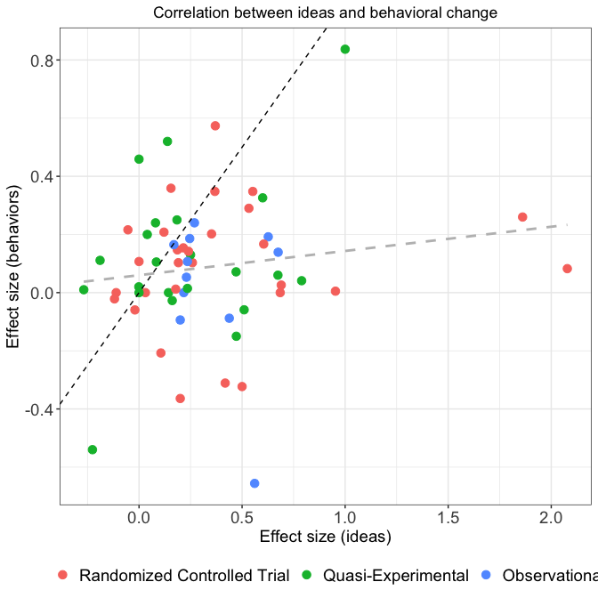

```r
sv_data |> filter(has_both == 'both') |>
  group_by(author, year, study_design, unique_study_id, scale_type) |>
  filter(delay == min(delay)) |>
  summarise(mean_d = mean(d),
         mean_var_d = mean(var_d),
         mean_se_d = mean(se_d)) |>
  pivot_wider(id_cols = c(author, year, unique_study_id, study_design),
    names_from = c(scale_type),
    values_from = c(mean_d, mean_var_d, mean_se_d)) |>
  ggplot(aes(x = mean_d_ideas,
             y = mean_d_behavior)) +
  geom_point(aes(color = study_design),
             size = 3) +
  geom_abline(slope = 1,
              lty = 'dashed') +
  geom_smooth(lty = "dashed",
              method = "lm",
              se = FALSE,
              color = 'grey') +
  labs(title = "Correlation between ideas and behavioral change",
       x = "Effect size (ideas)",
       y = "Effect size (behaviors)",
       color = "Study Design") +
 guides(color = guide_legend(title = "")) +
  theme_bw() +
  theme(plot.title = element_text(hjust = 0.5),
        axis.text = element_text(size = 14),
        axis.title = element_text(size = 14),
        legend.text = element_text(size = 14),
        legend.title = element_text(size = 14),
        legend.position = "bottom",
        legend.box = "vertical")
```

## 4 Creating a reproducible research environment

### 4.1 `write_dockerfile`

Once you’ve completed your analysis, you can use `write_dockerfile` to create a Docker container that captures your exact R environment. This ensures your analysis can be reproduced years later, even as R and package versions change.

The function converts the output from `sessionInfo()` into a Dockerfile that specifies: - Your R version - All loaded packages and their versions - System dependencies

```r
# After loading all packages you used in your analysis, run:
library(PaluckTools)
library(dplyr)
library(ggplot2)
# ... other packages you used

# Create a Dockerfile with all currently loaded packages
write_dockerfile()

# Or include ALL installed packages (not just loaded ones)
write_dockerfile(all_packages = TRUE)

# Preview the Dockerfile content without writing to file
write_dockerfile(write_file = FALSE)
```

This creates a file called `Dockerfile` in your current directory. You can then:

1. **Use it locally** with Docker to recreate your environment
2. **Share it with collaborators** so they can reproduce your exact setup
3. **Upload it to services like [mybinder.org](https://mybinder.org/)** to create an interactive online version of your analysis

For more on using Dockerfiles with R, see the [Rocker Project](https://www.rocker-project.org/) ([Boettiger & Eddelbuettel, 2017](https://arxiv.org/abs/1710.03675)).

### 4.2 Why reproducibility matters

Meta-analyses aggregate results from dozens or hundreds of studies. The calculations can be complex, with many judgment calls about inclusion criteria, effect size conversions, and subgroup analyses. Creating a reproducible environment ensures that:

- Reviewers can verify your analysis
- Future researchers can extend your work
- You can revisit your analysis years later and understand exactly what you did
- Your work contributes to open science practices

The `write_dockerfile` function makes this process straightforward by automatically capturing all the dependencies your analysis needs.